# Part I - Data Analysis and Visualization of Prosper Loan Data

## Introduction

> This data set contains **113,937 loans with 81 variables on each loan**, including loan amount, borrower rate (or interest rate), current loan status, borrower income, and many others. Below are a brief description of the variables.
- **ListingKey :** Unique key for each listing, same value as the 'key' used in the listing object in the API.
- **ListingNumber :** The number that uniquely identifies the listing to the public as displayed on the website.
- **ListingCreationDate :** The date the listing was created.
- **CreditGrade :** The Credit rating that was assigned at the time the listing went live. Applicable for listings pre-2009 period and will only be populated for those listings.
- **Term :** The length of the loan expressed in months.
- **LoanStatus :** The current status of the loan: Cancelled, Chargedoff, Completed, Current, Defaulted, FinalPaymentInProgress, PastDue. The PastDue status will be accompanied by a delinquency bucket.
- **ClosedDate :** Closed date is applicable for Cancelled, Completed, Chargedoff and Defaulted loan statuses.
- **BorrowerAPR :** The Borrower's Annual Percentage Rate (APR) for the loan.
- **BorrowerRate :** The Borrower's interest rate for this loan.
- **LenderYield :** The Lender yield on the loan. Lender yield is equal to the interest rate on the loan less the servicing fee.
- **EstimatedEffectiveYield :** Effective yield is equal to the borrower interest rate (i) minus the servicing fee rate, (ii) minus estimated uncollected interest on charge-offs, (iii) plus estimated collected late fees. Applicable for loans originated after July 2009.
- **EstimatedLoss :** Estimated loss is the estimated principal loss on charge-offs. Applicable for loans originated after July 2009.
- **EstimatedReturn :** The estimated return assigned to the listing at the time it was created. Estimated return is the difference between the Estimated Effective Yield and the Estimated Loss Rate. Applicable for loans originated after July 2009.
- **ProsperRating (numeric) :** The Prosper Rating assigned at the time the listing was created: 0 - N/A, 1 - HR, 2 - E, 3 - D, 4 - C, 5 - B, 6 - A, 7 - AA. Applicable for loans originated after July 2009.
- **ProsperRating (Alpha) :** The Prosper Rating assigned at the time the listing was created between AA - HR. Applicable for loans originated after July 2009.
- **ProsperScore:** A custom risk score built using historical Prosper data. The score ranges from 1-10, with 10 being the best, or lowest risk score. Applicable for loans originated after July 2009.
- **ListingCategory :** The category of the listing that the borrower selected when posting their listing: 0 - Not Available, 1 - Debt Consolidation, 2 - Home Improvement, 3 - Business, 4 - Personal Loan, 5 - Student Use, 6 - Auto, 7- Other, 8 - Baby&Adoption, 9 - Boat, 10 - Cosmetic Procedure, 11 - Engagement Ring, 12 - Green Loans, 13 - Household Expenses, 14 - Large Purchases, 15 - Medical/Dental, 16 - Motorcycle, 17 - RV, 18 - Taxes, 19 - Vacation, 20 - Wedding Loans
- **BorrowerState :** The two letter abbreviation of the state of the address of the borrower at the time the Listing was created.
- **Occupation :** The Occupation selected by the Borrower at the time they created the listing.
- **EmploymentStatus :** The employment status of the borrower at the time they posted the listing.
- **EmploymentStatusDuration :** The length in months of the employment status at the time the listing was created.
- **IsBorrowerHomeowner :** A Borrower will be classified as a homowner if they have a mortgage on their credit profile or provide documentation confirming they are a homeowner.
- **CurrentlyInGroup :** Specifies whether or not the Borrower was in a group at the time the listing was created.
- **GroupKey :** The Key of the group in which the Borrower is a member of. Value will be null if the borrower does not have a group affiliation.
- **DateCreditPulled :** The date the credit profile was pulled.
- **CreditScoreRangeLower :** The lower value representing the range of the borrower's credit score as provided by a consumer credit rating agency.
- **CreditScoreRangeUpper :** The upper value representing the range of the borrower's credit score as provided by a consumer credit rating agency.
- **FirstRecordedCreditLine :** The date the first credit line was opened.
- **CurrentCreditLines :** Number of current credit lines at the time the credit profile was pulled.
- **OpenCreditLines :** Number of open credit lines at the time the credit profile was pulled.
- **TotalCreditLinespast7years :** Number of credit lines in the past seven years at the time the credit profile was pulled.
- **OpenRevolvingAccounts :** Number of open revolving accounts at the time the credit profile was pulled.
- **OpenRevolvingMonthlyPayment :** Monthly payment on revolving accounts at the time the credit profile was pulled.
- **InquiriesLast6Months :** Number of inquiries in the past six months at the time the credit profile was pulled.
- **TotalInquiries :** Total number of inquiries at the time the credit profile was pulled.
- **CurrentDelinquencies :** Number of accounts delinquent at the time the credit profile was pulled.
- **AmountDelinquent :** Dollars delinquent at the time the credit profile was pulled.
- **DelinquenciesLast7Years :** Number of delinquencies in the past 7 years at the time the credit profile was pulled.
- **PublicRecordsLast10Years :** Number of public records in the past 10 years at the time the credit profile was pulled.
- **PublicRecordsLast12Months :** Number of public records in the past 12 months at the time the credit profile was pulled.
- **RevolvingCreditBalance :** Dollars of revolving credit at the time the credit profile was pulled.
- **BankcardUtilization :** The percentage of available revolving credit that is utilized at the time the credit profile was pulled.
- **TotalTrades :** Number of trade lines ever opened at the time the credit profile was pulled.
- **TradesNeverDelinquent :** Number of trades that have never been delinquent at the time the credit profile was pulled.
- **TradesOpenedLast6Months :** Number of trades opened in the last 6 months at the time the credit profile was pulled.
- **DebtToIncomeRatio :** The debt to income ratio of the borrower at the time the credit profile was pulled. This value is Null if the debt to income ratio is not available. This value is capped at 10.01 (any debt to income ratio larger than 1000% will be returned as 1001%).
- **IncomeRange :** The income range of the borrower at the time the listing was created.
- **IncomeVerifiable :** The borrower indicated they have the required documentation to support their income.
- **StatedMonthlyIncome :** The monthly income the borrower stated at the time the listing was created.
- **LoanKey :** Unique key for each loan. This is the same key that is used in the API.
- **TotalProsperLoans :** Number of Prosper loans the borrower at the time they created this listing. This value will be null if the borrower had no prior loans.
- **TotalProsperPaymentsBilled :** Number of on time payments the borrower made on Prosper loans at the time they created this listing. This value will be null if the borrower had no prior loans.
- **OnTimeProsperPayments :** Number of on time payments the borrower had made on Prosper loans at the time they created this listing. This value will be null if the borrower has no prior loans.
- **ProsperPaymentsLessThanOneMonthLate :** Number of payments the borrower made on Prosper loans that were less than one month late at the time they created this listing. This value will be null if the borrower had no prior loans.
- **ProsperPaymentsOneMonthPlusLate :** Number of payments the borrower made on Prosper loans that were greater than one month late at the time they created this listing. This value will be null if the borrower had no prior loans.
- **ProsperPrincipalBorrowed :** Total principal borrowed on Prosper loans at the time the listing was created. This value will be null if the borrower had no prior loans.
- **ProsperPrincipalOutstanding :** Principal outstanding on Prosper loans at the time the listing was created. This value will be null if the borrower had no prior loans.
- **ScorexChangeAtTimeOfListing :** Borrower's credit score change at the time the credit profile was pulled. This will be the change relative to the borrower's last Prosper loan. This value will be null if the borrower had no prior loans.
- **LoanCurrentDaysDelinquent :** The number of days delinquent.
- **LoanFirstDefaultedCycleNumber :** The cycle the loan was charged off. If the loan has not charged off the value will be null.
- **LoanMonthsSinceOrigination :** Number of months since the loan originated.
- **LoanNumber :** Unique numeric value associated with the loan.
- **LoanOriginalAmount :** The origination amount of the loan.
- **LoanOriginationDate :** The date the loan was originated.
- **LoanOriginationQuarter :** The quarter in which the loan was originated.
- **MemberKey :** The unique key that is associated with the borrower. This is the same identifier that is used in the API member object.
- **MonthlyLoanPayment :** The scheduled monthly loan payment.
- **LP_CustomerPayments :** Pre charge-off cumulative gross payments made by the borrower on the loan. If the loan has charged off, this value will exclude any recoveries.
- **LP_CustomerPrincipalPayments :** Pre charge-off cumulative principal payments made by the borrower on the loan. If the loan has charged off, this value will exclude any recoveries.
- **LP_InterestandFees :** Pre charge-off cumulative interest and fees paid by the borrower. If the loan has charged off, this value will exclude any recoveries.
- **LP_ServiceFees :** Cumulative service fees paid by the investors who have invested in the loan.
- **LP_CollectionFees :** Cumulative collection fees paid by the investors who have invested in the loan.
- **LP_GrossPrincipalLoss :** The gross charged off amount of the loan.
- **LP_NetPrincipalLoss :** The principal that remains uncollected after any recoveries.
- **LP_NonPrincipalRecoverypayments :** The interest and fee component of any recovery payments. The current payment policy applies payments in the following order: Fees, interest, principal.
- **PercentFunded :** Percent the listing was funded.
- **Recommendations :** Number of recommendations the borrower had at the time the listing was created.
- **InvestmentFromFriendsCount :** Number of friends that made an investment in the loan.
- **InvestmentFromFriendsAmount :** Dollar amount of investments that were made by friends.
- **Investors :** The number of investors that funded the loan.

## Preliminary Wrangling

```python
# import all packages and set plots to be embedded inline
import numpy as np
import pandas as pd
import matplotlib.pyplot as plt
import seaborn as sns

%matplotlib inline
```

```python
ProsperLoan = pd.read_csv('prosperLoanData.csv')
```

> ASSESSMENT (PROGRAMATIC & VISUAL)

```python
ProsperLoan.shape
```

```
(113937, 81)
```

```python
ProsperLoan.dtypes
```

```
ListingKey                      object
ListingNumber                    int64
ListingCreationDate             object
CreditGrade                     object
Term                             int64
                                ...
PercentFunded                  float64
Recommendations                  int64
InvestmentFromFriendsCount       int64
InvestmentFromFriendsAmount    float64
Investors                        int64
Length: 81, dtype: object
```

```python
ProsperLoan.describe()
```

|  | ListingNumber | Term | BorrowerAPR | BorrowerRate | LenderYield | EstimatedEffectiveYield | EstimatedLoss | EstimatedReturn | ProsperRating (numeric) | ProsperScore | ... | LP_ServiceFees | LP_CollectionFees | LP_GrossPrincipalLoss | LP_NetPrincipalLoss | LP_NonPrincipalRecoverypayments | PercentFunded | Recommendations | InvestmentFromFriendsCount | InvestmentFromFriendsAmount | Investors |
| --- | --- | --- | --- | --- | --- | --- | --- | --- | --- | --- | --- | --- | --- | --- | --- | --- | --- | --- | --- | --- | --- |
| count | 1.139370e+05 | 113937.000000 | 113912.000000 | 113937.000000 | 113937.000000 | 84853.000000 | 84853.000000 | 84853.000000 | 84853.000000 | 84853.000000 | ... | 113937.000000 | 113937.000000 | 113937.000000 | 113937.000000 | 113937.000000 | 113937.000000 | 113937.000000 | 113937.000000 | 113937.000000 | 113937.000000 |
| mean | 6.278857e+05 | 40.830248 | 0.218828 | 0.192764 | 0.182701 | 0.168661 | 0.080306 | 0.096068 | 4.072243 | 5.950067 | ... | -54.725641 | -14.242698 | 700.446342 | 681.420499 | 25.142686 | 0.998584 | 0.048027 | 0.023460 | 16.550751 | 80.475228 |
| std | 3.280762e+05 | 10.436212 | 0.080364 | 0.074818 | 0.074516 | 0.068467 | 0.046764 | 0.030403 | 1.673227 | 2.376501 | ... | 60.675425 | 109.232758 | 2388.513831 | 2357.167068 | 275.657937 | 0.017919 | 0.332353 | 0.232412 | 294.545422 | 103.239020 |
| min | 4.000000e+00 | 12.000000 | 0.006530 | 0.000000 | -0.010000 | -0.182700 | 0.004900 | -0.182700 | 1.000000 | 1.000000 | ... | -664.870000 | -9274.750000 | -94.200000 | -954.550000 | 0.000000 | 0.700000 | 0.000000 | 0.000000 | 0.000000 | 1.000000 |
| 25% | 4.009190e+05 | 36.000000 | 0.156290 | 0.134000 | 0.124200 | 0.115670 | 0.042400 | 0.074080 | 3.000000 | 4.000000 | ... | -73.180000 | 0.000000 | 0.000000 | 0.000000 | 0.000000 | 1.000000 | 0.000000 | 0.000000 | 0.000000 | 2.000000 |
| 50% | 6.005540e+05 | 36.000000 | 0.209760 | 0.184000 | 0.173000 | 0.161500 | 0.072400 | 0.091700 | 4.000000 | 6.000000 | ... | -34.440000 | 0.000000 | 0.000000 | 0.000000 | 0.000000 | 1.000000 | 0.000000 | 0.000000 | 0.000000 | 44.000000 |
| 75% | 8.926340e+05 | 36.000000 | 0.283810 | 0.250000 | 0.240000 | 0.224300 | 0.112000 | 0.116600 | 5.000000 | 8.000000 | ... | -13.920000 | 0.000000 | 0.000000 | 0.000000 | 0.000000 | 1.000000 | 0.000000 | 0.000000 | 0.000000 | 115.000000 |
| max | 1.255725e+06 | 60.000000 | 0.512290 | 0.497500 | 0.492500 | 0.319900 | 0.366000 | 0.283700 | 7.000000 | 11.000000 | ... | 32.060000 | 0.000000 | 25000.000000 | 25000.000000 | 21117.900000 | 1.012500 | 39.000000 | 33.000000 | 25000.000000 | 1189.000000 |

8 rows × 61 columns

```python
ProsperLoan.info()
```

```
<class 'pandas.core.frame.DataFrame'>
RangeIndex: 113937 entries, 0 to 113936
Data columns (total 81 columns):
 #   Column                               Non-Null Count   Dtype
---  ------                               --------------   -----
 0   ListingKey                           113937 non-null  object
 1   ListingNumber                        113937 non-null  int64
 2   ListingCreationDate                  113937 non-null  object
 3   CreditGrade                          28953 non-null   object
 4   Term                                 113937 non-null  int64
 5   LoanStatus                           113937 non-null  object
 6   ClosedDate                           55089 non-null   object
 7   BorrowerAPR                          113912 non-null  float64
 8   BorrowerRate                         113937 non-null  float64
 9   LenderYield                          113937 non-null  float64
```

[output cut: 73 more lines]

```python
ProsperLoan.sample(10)
```

|  | ListingKey | ListingNumber | ListingCreationDate | CreditGrade | Term | LoanStatus | ClosedDate | BorrowerAPR | BorrowerRate | LenderYield | ... | LP_ServiceFees | LP_CollectionFees | LP_GrossPrincipalLoss | LP_NetPrincipalLoss | LP_NonPrincipalRecoverypayments | PercentFunded | Recommendations | InvestmentFromFriendsCount | InvestmentFromFriendsAmount | Investors |
| --- | --- | --- | --- | --- | --- | --- | --- | --- | --- | --- | --- | --- | --- | --- | --- | --- | --- | --- | --- | --- | --- |
| 26015 | 6F4C34239914355005C9E44 | 354840 | 2008-06-21 14:53:49.913000000 | B | 36 | Completed | 2011-03-23 00:00:00 | 0.19462 | 0.1800 | 0.1700 | ... | -248.55 | 0.0 | 0.00 | 0.00 | 0.0 | 1.0 | 1 | 1 | 500.0 | 364 |
| 64021 | C1783390012891104E84E10 | 138933 | 2007-05-17 05:59:13.020000000 | C | 36 | Chargedoff | 2008-04-30 00:00:00 | 0.15723 | 0.1501 | 0.1401 | ... | -52.05 | 0.0 | 9493.10 | 9493.10 | 0.0 | 1.0 | 0 | 0 | 0.0 | 160 |
| 99740 | 26B034126938423812E0F18 | 272954 | 2008-01-29 06:45:40.657000000 | D | 36 | Completed | 2009-11-20 00:00:00 | 0.37372 | 0.3492 | 0.3392 | ... | -56.84 | 0.0 | 0.00 | 0.00 | 0.0 | 1.0 | 1 | 0 | 0.0 | 29 |
| 6325 | 9D7E3593519555474A16E14 | 1010843 | 2013-11-11 11:48:04.280000000 | NaN | 36 | Current | NaN | 0.14816 | 0.1199 | 0.1099 | ... | -49.22 | 0.0 | 0.00 | 0.00 | 0.0 | 1.0 | 0 | 0 | 0.0 | 1 |
| 4856 | 612535237134355976934B0 | 523773 | 2011-08-23 23:32:50.923000000 | NaN | 36 | Completed | 2012-02-01 00:00:00 | 0.22362 | 0.1899 | 0.1799 | ... | -7.96 | 0.0 | 0.00 | 0.00 | 0.0 | 1.0 | 0 | 0 | 0.0 | 6 |
| 42475 | B8A03583795530655E69509 | 835306 | 2013-07-10 18:57:44.793000000 | NaN | 36 | Current | NaN | 0.31032 | 0.2712 | 0.2612 | ... | -11.11 | 0.0 | 0.00 | 0.00 | 0.0 | 1.0 | 0 | 0 | 0.0 | 1 |
| 101093 | 94A13501192190956711944 | 485914 | 2010-11-27 21:43:26.577000000 | NaN | 36 | Defaulted | 2011-12-06 00:00:00 | 0.33097 | 0.2950 | 0.2850 | ... | -19.77 | 0.0 | 3119.96 | 3119.96 | 0.0 | 1.0 | 0 | 0 | 0.0 | 75 |
| 52325 | 0AEC3553723100653DFB2FE | 613370 | 2012-07-17 18:20:07.977000000 | NaN | 36 | Current | NaN | 0.14328 | 0.1151 | 0.1051 | ... | -123.57 | 0.0 | 0.00 | 0.00 | 0.0 | 1.0 | 0 | 0 | 0.0 | 156 |
| 74450 | F2183569920994330C047F0 | 706697 | 2013-02-01 10:34:48.527000000 | NaN | 60 | Current | NaN | 0.17522 | 0.1519 | 0.1419 | ... | -119.16 | 0.0 | 0.00 | 0.00 | 0.0 | 1.0 | 0 | 0 | 0.0 | 136 |
| 22184 | 28313602695582094E5CFD0 | 1194302 | 2014-02-14 11:05:13.080000000 | NaN | 36 | Current | NaN | 0.18671 | 0.1500 | 0.1400 | ... | 0.00 | 0.0 | 0.00 | 0.00 | 0.0 | 1.0 | 0 | 0 | 0.0 | 14 |

10 rows × 81 columns

```python
ProsperLoan['ProsperRating (Alpha)'].value_counts()
```

```
C     18345
B     15581
A     14551
D     14274
E      9795
HR     6935
AA     5372
Name: ProsperRating (Alpha), dtype: int64
```

```python
ProsperLoan['ProsperRating (numeric)'].value_counts()
```

```
4.0    18345
5.0    15581
6.0    14551
3.0    14274
2.0     9795
1.0     6935
7.0     5372
Name: ProsperRating (numeric), dtype: int64
```

## `CLEANING`

```python
# Making a copy of the dataset
df_loan = ProsperLoan.copy()
```

```python
pd.set_option('mode.chained_assignment', None) #ignoring warning message on copy chained

# selecting columns needed for my analysis
df_loan_clean = df_loan[['ClosedDate','CreditGrade','Term','LoanStatus','BorrowerAPR',
                        'BorrowerRate','IsBorrowerHomeowner','ListingCategory (numeric)',
                         'EmploymentStatus','ProsperRating (Alpha)','EstimatedReturn','ProsperScore','IncomeRange',
                        'LoanOriginalAmount','CreditScoreRangeLower','CreditScoreRangeUpper',
                        'StatedMonthlyIncome']]
```

```python
# Format ClosedDate as Date
df_loan_clean['ClosedDate'] = pd.to_datetime(df_loan_clean.ClosedDate)
```

```python
# Create a ListingCategory with the actual category names
case = [(df_loan_clean['ListingCategory (numeric)']==1),(df_loan_clean['ListingCategory (numeric)']==2),
        (df_loan_clean['ListingCategory (numeric)']==3),(df_loan_clean['ListingCategory (numeric)']==4),
        (df_loan_clean['ListingCategory (numeric)']==5),(df_loan_clean['ListingCategory (numeric)']==6),
        (df_loan_clean['ListingCategory (numeric)']==7),(df_loan_clean['ListingCategory (numeric)']==8),
        (df_loan_clean['ListingCategory (numeric)']==9),(df_loan_clean['ListingCategory (numeric)']==10),
        (df_loan_clean['ListingCategory (numeric)']==11),(df_loan_clean['ListingCategory (numeric)']==12),
        (df_loan_clean['ListingCategory (numeric)']==13),(df_loan_clean['ListingCategory (numeric)']==14),
        (df_loan_clean['ListingCategory (numeric)']==15),(df_loan_clean['ListingCategory (numeric)']==16),
        (df_loan_clean['ListingCategory (numeric)']==17),(df_loan_clean['ListingCategory (numeric)']==18),
        (df_loan_clean['ListingCategory (numeric)']==19),(df_loan_clean['ListingCategory (numeric)']==20)]

output = ['Debt Consolidation','Home Improvement','Business','Personal Loan','Student Use',
         'Auto','Other','Baby&Adoption','Boat','Cosmetic Procedure','Engagement Ring','Green Loans','Household Expenses',
         'Large Purchases', 'Medical','Motorcycle','RV','Taxes','Vacation','Wedding Loans']

Result = np.select(case, output, default='Not Available')

df_loan_clean['ListingCategory'] = pd.Series(Result)
```

```python
# dropping ListingCategory numeric column
df_loan_clean.drop('ListingCategory (numeric)', axis=1, inplace=True)
```

```python
# Creating ordered categorical list for LoanStatus, ProsperRating (Alpha), IncomeRange, EmploymentStatus
dict = {'ProsperRating (Alpha)':['AA','A','B','C','D','E','HR'],
       'LoanStatus':['Current', 'Completed', 'FinalPaymentInProgress', 'Chargedoff', 'Defaulted', 'Cancelled',
                    'Past Due (1-15 days)', 'Past Due (16-30 days)', 'Past Due (31-60 days)','Past Due (61-90 days)',
                     'Past Due (91-120 days)', 'Past Due (>120 days)'],
       'IncomeRange': ['Not displayed', 'Not employed', '$0', '$1-24,999', '$25,000-49,999', '$50,000-74,999',
                                    '$75,000-99,999', '$100,000+'],
       'EmploymentStatus': ['Employed', 'Full-time', 'Part-time', 'Self-employed', 'Retired', 'Not employed', 'Other',
                                        'Not available']
       }
for key in dict:
    Order = pd.api.types.CategoricalDtype(ordered=True, categories=dict[key])
    df_loan_clean[key] = df_loan_clean[key].astype(Order)

# converting the following variables to categorical datatype
df_loan_clean['ListingCategory'] = df_loan_clean.ListingCategory.astype('category')

# Loan are grouped into three Terms 12, 36, 60 is better to treat as categorical
df_loan_clean['Term'] = df_loan_clean.Term.astype('category')
```

## Test

```python
df_loan_clean.shape
```

```
(113937, 17)
```

```python
df_loan_clean.head()
```

|  | ClosedDate | CreditGrade | Term | LoanStatus | BorrowerAPR | BorrowerRate | IsBorrowerHomeowner | EmploymentStatus | ProsperRating (Alpha) | EstimatedReturn | ProsperScore | IncomeRange | LoanOriginalAmount | CreditScoreRangeLower | CreditScoreRangeUpper | StatedMonthlyIncome | ListingCategory |
| --- | --- | --- | --- | --- | --- | --- | --- | --- | --- | --- | --- | --- | --- | --- | --- | --- | --- |
| 0 | 2009-08-14 | C | 36 | Completed | 0.16516 | 0.1580 | True | Self-employed | NaN | NaN | NaN | $25,000-49,999 | 9425 | 640.0 | 659.0 | 3083.333333 | Not Available |
| 1 | NaT | NaN | 36 | Current | 0.12016 | 0.0920 | False | Employed | A | 0.05470 | 7.0 | $50,000-74,999 | 10000 | 680.0 | 699.0 | 6125.000000 | Home Improvement |
| 2 | 2009-12-17 | HR | 36 | Completed | 0.28269 | 0.2750 | False | Not available | NaN | NaN | NaN | Not displayed | 3001 | 480.0 | 499.0 | 2083.333333 | Not Available |
| 3 | NaT | NaN | 36 | Current | 0.12528 | 0.0974 | True | Employed | A | 0.06000 | 9.0 | $25,000-49,999 | 10000 | 800.0 | 819.0 | 2875.000000 | Motorcycle |
| 4 | NaT | NaN | 36 | Current | 0.24614 | 0.2085 | True | Employed | D | 0.09066 | 4.0 | $100,000+ | 15000 | 680.0 | 699.0 | 9583.333333 | Home Improvement |

```python
df_loan_clean.dtypes
```

```
ClosedDate               datetime64[ns]
CreditGrade                      object
Term                           category
LoanStatus                     category
BorrowerAPR                     float64
BorrowerRate                    float64
IsBorrowerHomeowner                bool
EmploymentStatus               category
ProsperRating (Alpha)          category
EstimatedReturn                 float64
ProsperScore                    float64
IncomeRange                    category
LoanOriginalAmount                int64
CreditScoreRangeLower           float64
CreditScoreRangeUpper           float64
StatedMonthlyIncome             float64
ListingCategory                category
dtype: object
```

```python
df_loan_clean.ListingCategory.value_counts()
```

```
Debt Consolidation    58308
Not Available         16965
Other                 10494
Home Improvement       7433
Business               7189
Auto                   2572
Personal Loan          2395
Household Expenses     1996
Medical                1522
Taxes                   885
Large Purchases         876
Wedding Loans           771
Vacation                768
Student Use             756
Motorcycle              304
Engagement Ring         217
Baby&Adoption           199
Cosmetic Procedure       91
Boat                     85
Green Loans              59
RV                       52
Name: ListingCategory, dtype: int64
```

```python
df_loan_clean['ProsperRating (Alpha)'].value_counts()
```

```
C     18345
B     15581
A     14551
D     14274
E      9795
HR     6935
AA     5372
Name: ProsperRating (Alpha), dtype: int64
```

```python
# saving the cleaned dataset for the explanatory analysis

prosperLoan = df_loan_clean.to_csv('prosperLoan.csv')
```

### What is the structure of your dataset?

> For the purpose of this analysis, the dataset has been reshaped to consist of **113937** rows and **17** columns

### What is/are the main feature(s) of interest in your dataset?

> For the purpose of this analysis, my interest is in borrower rate and it's effect on Loan status if any!

### What features in the dataset do you think will help support your investigation into your feature(s) of interest?

> The following features will be valuable to this analysis: Borrower rate, Loan Status, Listing Category, Loan Amount and Employment status

## Univariate Exploration

**What is major reason Borrowers apply for loans?**

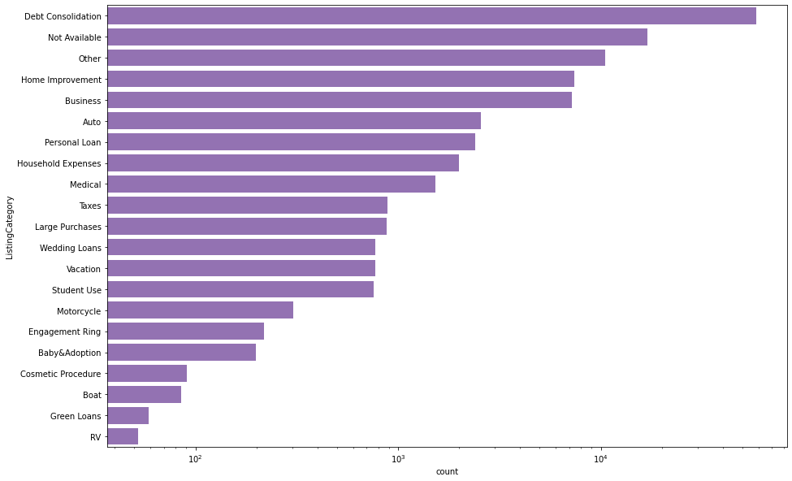

```python
plt.figure(figsize=(15,10))
order = df_loan_clean.ListingCategory.value_counts().index
color = sns.color_palette()[4]
sns.countplot(data=df_loan_clean, y='ListingCategory', color = color, order = order)
plt.xscale('log');
```

> The graph above shows the count of loans by ListingCategories on a log scale. Debt Consolidation ranked first among the categories

**Are Borrowers Home Owners?**

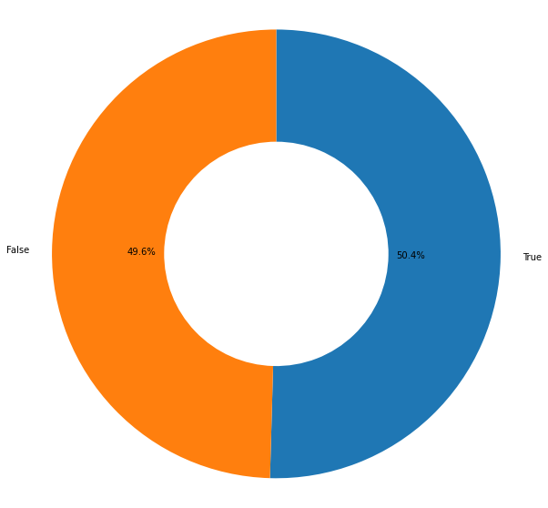

```python
pie_data = df_loan_clean.IsBorrowerHomeowner.value_counts()

plt.figure(figsize=(15,10))
plt.pie(pie_data, labels=pie_data.index, autopct='%1.1f%%', startangle=90, counterclock=False, wedgeprops={"width": 0.5})
plt.axis('square');
```

> The pie chart shows the percentage of Borrowers who owns a home versus Borrowers who do not own a home. 50.4% of Borrowers are home owners

```python
# Creating a function to plot subsequent countplots

def countplot(var):
    plt.figure(figsize=(15,10))
    var = df_loan_clean[var]
    g = sns.countplot(data=df_loan_clean, x=var, color=color);
```

**Which loans do Borrowers take the most? Highly rated loans?**

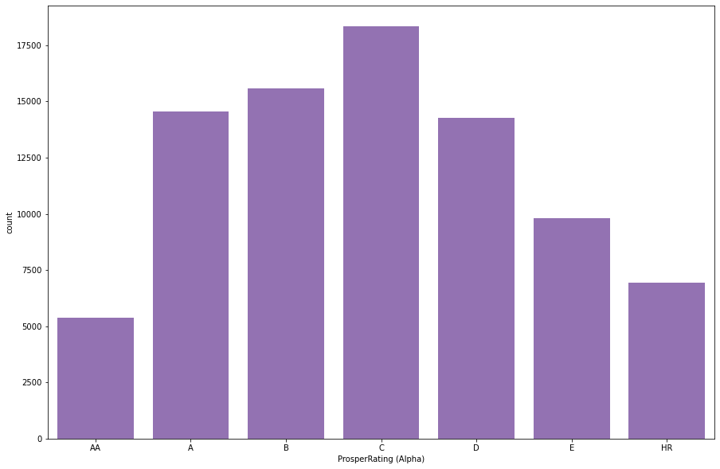

```python
countplot('ProsperRating (Alpha)')
```

> C rated Loans where the most preferred Loans Borrowers accepted. There is a fair distribution of borrowers among the A:D rated Loans

**Does Employment status have an effect on loans?**

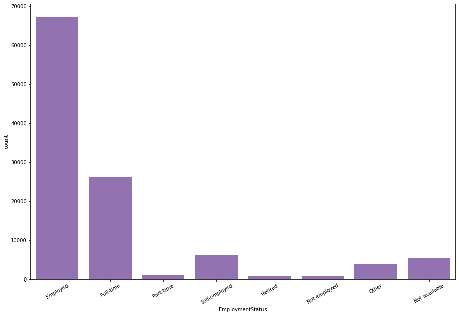

```python
countplot('EmploymentStatus')
plt.xticks(rotation=30);
```

> The chart above depicts that a fair majority of the borrowers are employed and mostly work full time

```python
df_loan.IncomeRange.value_counts()
```

```
$25,000-49,999    32192
$50,000-74,999    31050
$100,000+         17337
$75,000-99,999    16916
Not displayed      7741
$1-24,999          7274
Not employed        806
$0                  621
Name: IncomeRange, dtype: int64
```

**Which income range take loans the most?**

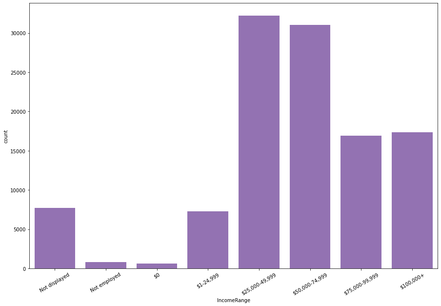

```python
countplot('IncomeRange')
plt.xticks(rotation=30);
```

**At what rates are most loans taken?**

```python
df_loan_clean[['BorrowerRate','EstimatedReturn']].describe()
```

|  | BorrowerRate | EstimatedReturn |
| --- | --- | --- |
| count | 113937.000000 | 84853.000000 |
| mean | 0.192764 | 0.096068 |
| std | 0.074818 | 0.030403 |
| min | 0.000000 | -0.182700 |
| 25% | 0.134000 | 0.074080 |
| 50% | 0.184000 | 0.091700 |
| 75% | 0.250000 | 0.116600 |
| max | 0.497500 | 0.283700 |

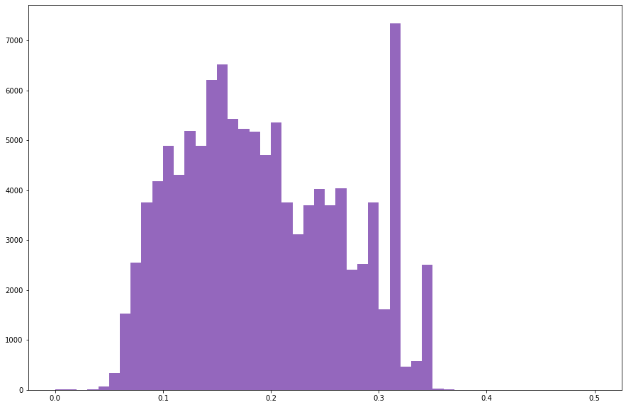

```python
plt.figure(figsize=(15,10))
bins = np.arange(0, 0.50+0.01, 0.01)
plt.hist(data=df_loan_clean, x='BorrowerRate', bins=bins, color=color);
```

> Although there's a spike around 0.31, majority of loans are taken at a rate of 0.1 - 0.2

**How is estimated return distributed?**

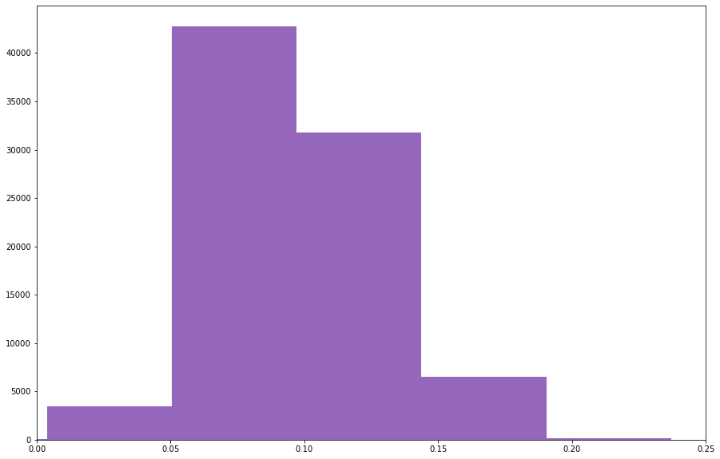

```python
plt.figure(figsize=(15,10))
bins = np.arange(0, df_loan_clean.EstimatedReturn.max()+0.01, 0.01)
plt.hist(data=df_loan_clean, x='EstimatedReturn', color=color)
plt.xlim((0,0.25));
```

> Expected return is at best between the rates of 0.05 - 0.15

**What amount of loans do borrowers take?**

```python
df_loan_clean.LoanOriginalAmount.describe()
```

```
count    113937.00000
mean       8337.01385
std        6245.80058
min        1000.00000
25%        4000.00000
50%        6500.00000
75%       12000.00000
max       35000.00000
Name: LoanOriginalAmount, dtype: float64
```

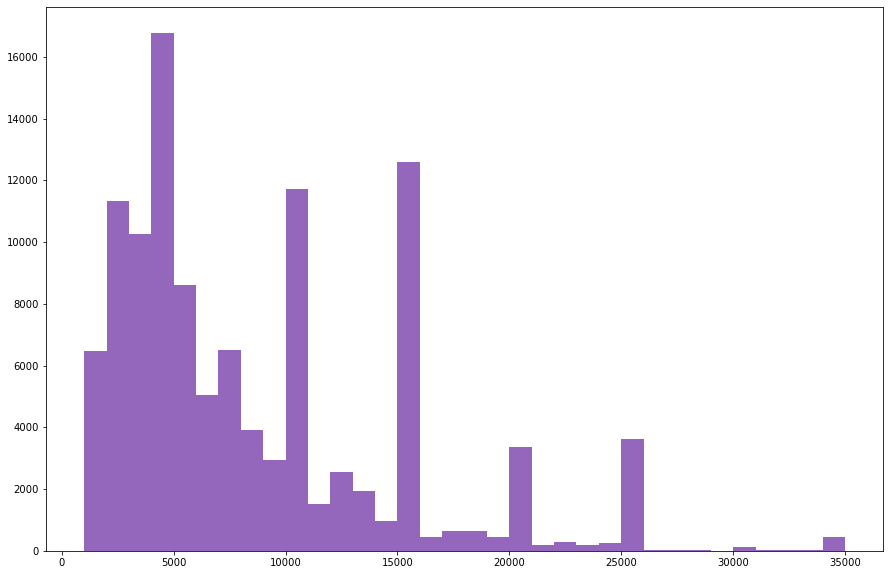

```python
# Create bins to group laons
Loan_Bins = np.arange(df_loan_clean.LoanOriginalAmount.min(), df_loan_clean.LoanOriginalAmount.max()+1000, 1000)
plt.figure(figsize=(15,10))
plt.hist(data=df_loan_clean, x='LoanOriginalAmount', bins=Loan_Bins, color = color);
```

### Discuss the distribution(s) of your variable(s) of interest. Were there any unusual points? Did you need to perform any transformations?

> Loans are given to borrowers who are employed and mostly work full time. Borrower rate is fairly distributed but there's an unusual spike around 0.32 which would be further investigated.

### Of the features you investigated, were there any unusual distributions? Did you perform any operations on the data to tidy, adjust, or change the form of the data? If so, why did you do this?

> Debt Consolidation was unusually high among the Listing catgories so I had to logarithmically transform the x-axis in order to visibly see the data points of the other Listing Categories

## Bivariate Exploration

**What is the correlation between the numeric variables of this dataset?**

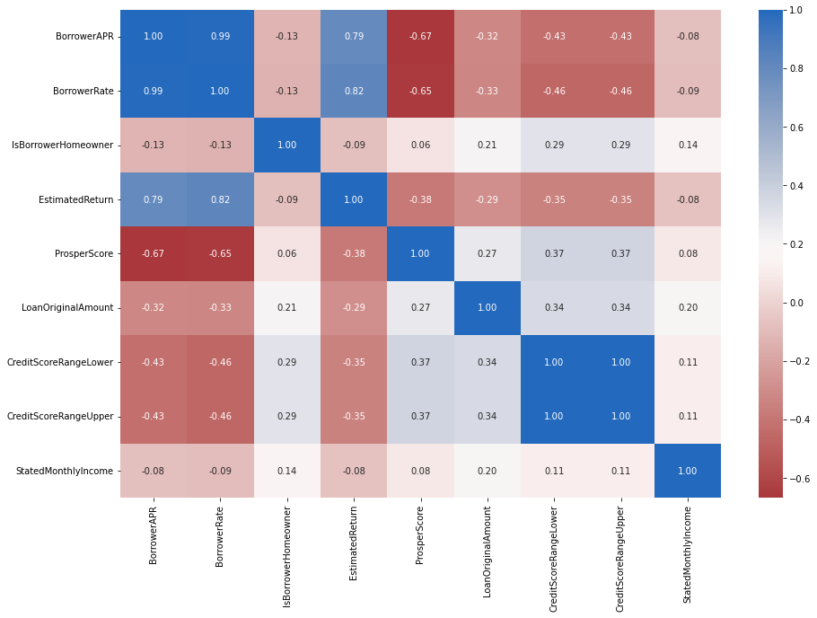

```python
plt.figure(figsize=(15,10))
sns.heatmap(df_loan_clean.corr(), annot=True, cmap='vlag_r', fmt='.2f');
```

Below are the correlation of interest:

- There is a positive correlation between Borrower Credit Score range and the Amount of loan granted with a correlation of 0.34
- There is a negative correlation between Borrower rate and Loan amount with a correlation of -0.33
- There is a negative correlation between Borrower rate and prosper score with a correlation of -0.65

**Does Interest rate affect Loan status?**

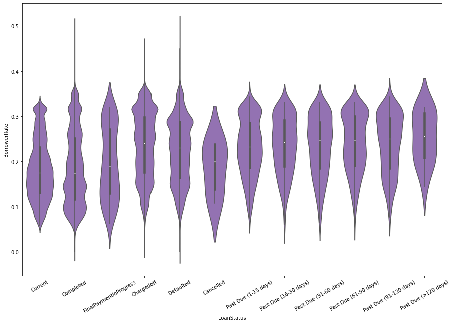

```python
plt.figure(figsize=(15,10))
sns.violinplot(data=df_loan_clean, x='LoanStatus', y='BorrowerRate', color=color)
plt.xticks(rotation=30);
```

**Does Rating influence Borrower Rate**

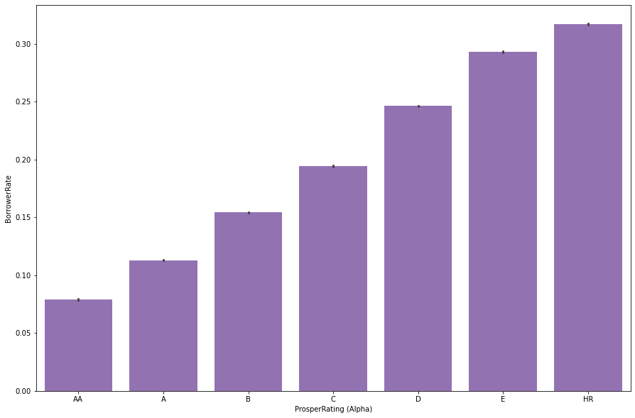

```python
plt.figure(figsize=(15,10))
sns.barplot(data=df_loan_clean, x='ProsperRating (Alpha)', y='BorrowerRate', color=color);
```

> This graph explains the negative correlation between Prosper score and Borrower rate shown by the heatmap. That is the higher the rating, the lower the interest rate and vice versa

**Is there a relationship between Borrower's credit score and amount of loan granted?**

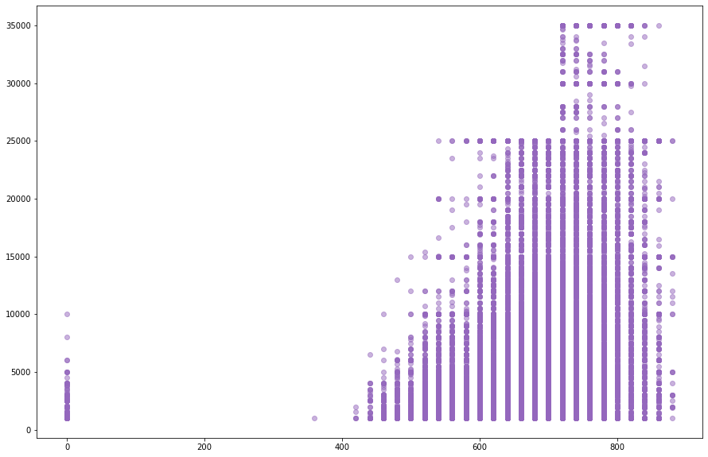

```python
plt.figure(figsize=(15,10))
plt.scatter(data=df_loan_clean, x='CreditScoreRangeLower', y='LoanOriginalAmount', color=color, alpha=0.5);
```

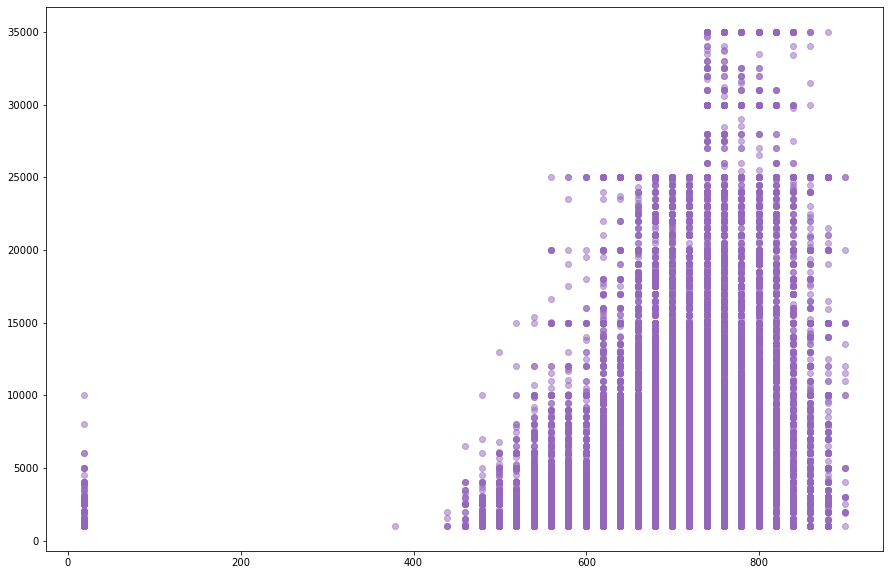

```python
plt.figure(figsize=(15,10))
plt.scatter(data=df_loan_clean, x='CreditScoreRangeUpper', y='LoanOriginalAmount', color=color, alpha=0.5);
```

> Though there seem not to be a clear pattern between Borrower credit score and loan amount, it is however evident that higher loans were granted to customers with higher credit score

**Does Income Range have an effect on loan amount?**

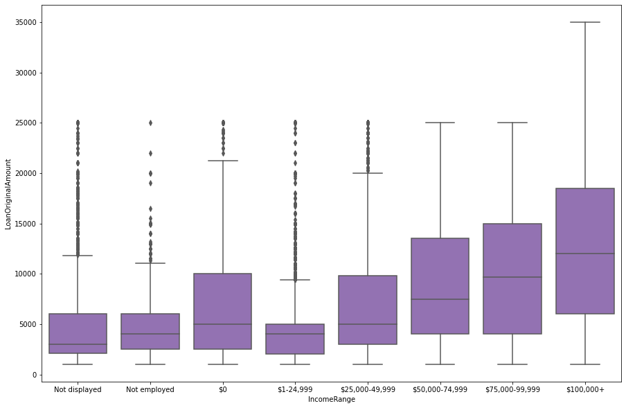

```python
plt.figure(figsize=(15,10))
sns.boxplot(data=df_loan_clean, x='IncomeRange', y='LoanOriginalAmount', color=color);
```

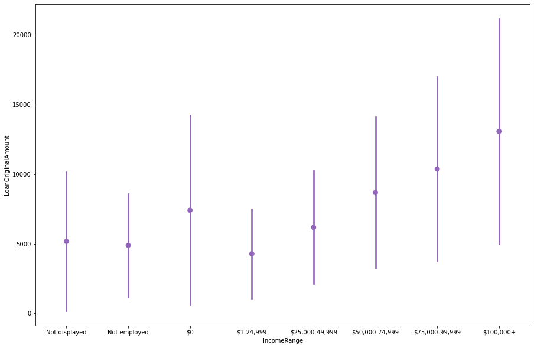

```python
plt.figure(figsize=(15,10))
sns.pointplot(data=df_loan_clean, x='IncomeRange', y='LoanOriginalAmount', color=color,
             ci='sd', linestyles="");
```

> The line plot ehxibits clearly, with the exception of $0, the mean for loan amount increases with increased Income range

**Does Stated Monthly Income affect Original Loan Amount?**

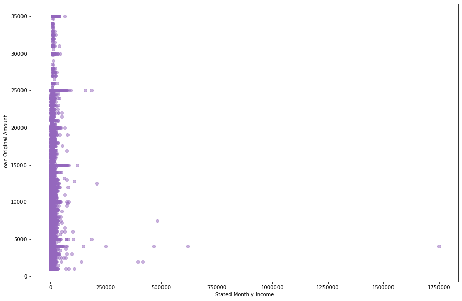

```python
plt.figure(figsize=(15,10))
plt.ticklabel_format(style='plain')
plt.scatter(data=df_loan_clean, x='StatedMonthlyIncome', y='LoanOriginalAmount', color=color, alpha=0.5)
plt.xlabel('Stated Monthly Income')
plt.ylabel('Loan Original Amount');
```

> From the graph above, it is clear majority of borrowers earn around $100,000 and below and this imepeds the pattern depicted by the graph so in order to avoid overplotting, a further analysis will be made using a random sample of 1000 borrowers

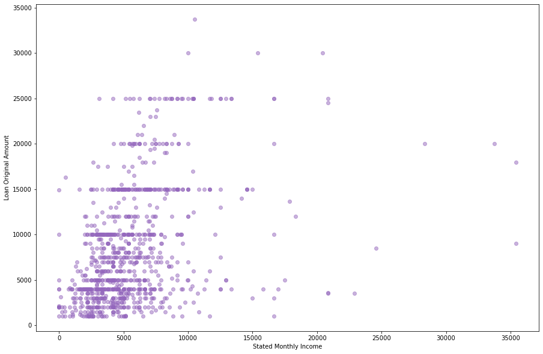

```python
# ploting a sample of 1000 from the data
np.random.seed(1)
sample = np.random.choice(df_loan_clean.shape[0], 1000, replace=False)
scatter_data = df_loan_clean.loc[sample]


plt.figure(figsize=(15,10))
plt.scatter(data=scatter_data, x='StatedMonthlyIncome', y='LoanOriginalAmount', color=color, alpha=0.5)
plt.xlabel('Stated Monthly Income')
plt.ylabel('Loan Original Amount');
```

> Though not always the case, stated monthly income does have an effect on the amount of loans granted

### Talk about some of the relationships you observed in this part of the investigation. How did the feature(s) of interest vary with other features in the dataset?

> There is a verifiable relationship between loan status and borrower rate as completed loans have an average borrower rate lower than Defaulted Loans. There is a positive relationship between income range and amount of loan granted which is expected.

### Did you observe any interesting relationships between the other features (not the main feature(s) of interest)?

> Prosper rating is negatively correlated with borrower rate and a positive relationship between borrowers who are home owners and their credit score

## Multivariate Exploration

**How does Borrower rate impact the status of the Borrowed amount?**

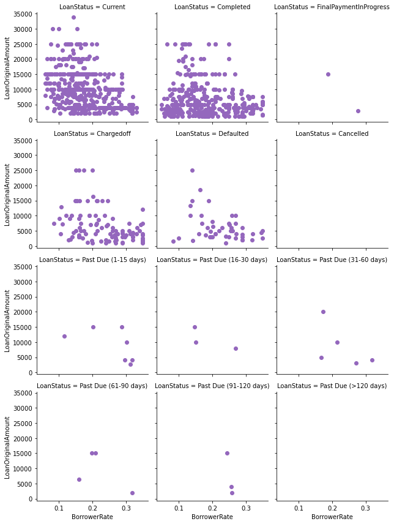

```python
g = sns.FacetGrid(data=scatter_data, col='LoanStatus', col_wrap=3)
g.map(plt.scatter, 'BorrowerRate', 'LoanOriginalAmount', color=color);
```

**Which Listing Categories are more likely to complete, default or have their loans charged off?**

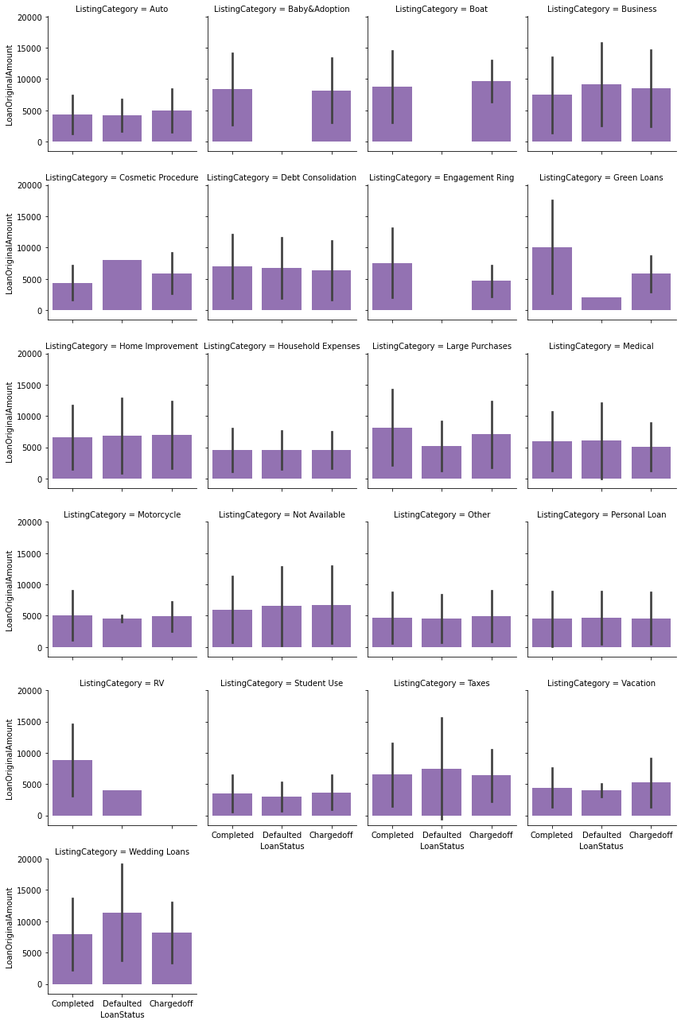

```python
# slicing the Loan status column to just three variables: Completed, defaulted, Charged off

status = ['Completed', 'Defaulted', 'Chargedoff']
loan_data = df_loan_clean.loc[df_loan_clean['LoanStatus'].isin(status)]

g = sns.FacetGrid(data=loan_data, col='ListingCategory', col_wrap=4)
g.map(sns.barplot, 'LoanStatus', 'LoanOriginalAmount', ci='sd', order=status, color=color);
```

**Does Term (Number of months) affect ability to settle loan amounts?**

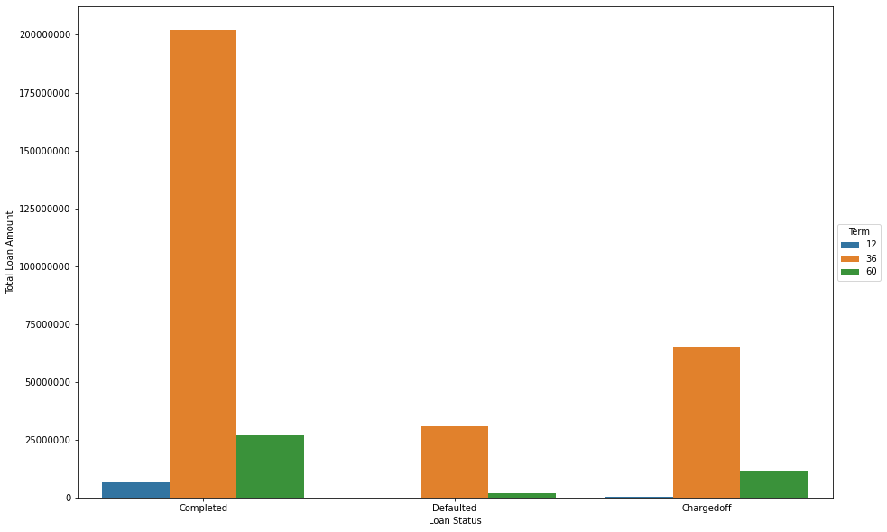

```python
plt.figure(figsize=(15,10))
plt.ticklabel_format(style='plain') # getting rid of le6 labels
sns.barplot(data=loan_data, x='LoanStatus', y='LoanOriginalAmount',
              hue='Term', estimator=sum, ci=None, order=status)
plt.xlabel('Loan Status')
plt.ylabel('Total Loan Amount');
plt.legend(loc = 6, bbox_to_anchor = (1.0, 0.5), title='Term'); # legend to right of figure
```

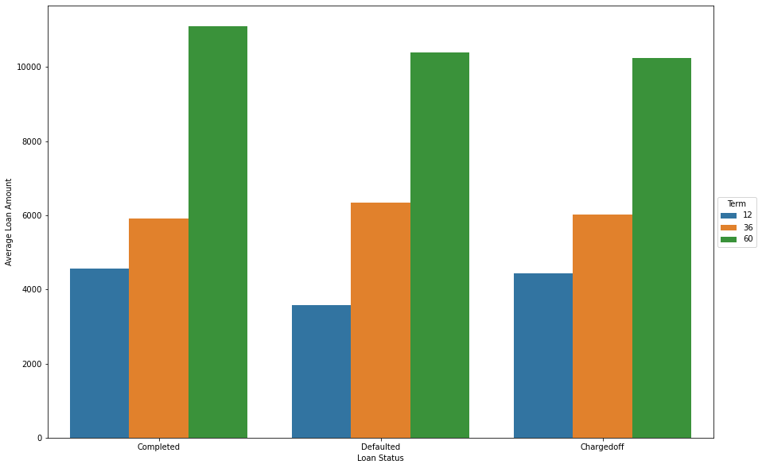

```python
plt.figure(figsize=(15,10))

sns.barplot(data=loan_data, x='LoanStatus', y='LoanOriginalAmount',
              hue='Term', ci=None, order=status)
plt.xlabel('Loan Status')
plt.ylabel('Average Loan Amount');
plt.legend(loc = 6, bbox_to_anchor = (1.0, 0.5), title='Term'); # legend to right of figure
```

> On the average, Number of months for loan settlement does not impact the loan status. The pattern is similar across all loan statuses

### Were there any interesting or surprising interactions between features?

> It's surprising the terms of the loan (number of months required to settle the loan) on average, has no significant impact on the Loan status